# Model_Selection

|  | Forward-Selection | Backward-Elimination | Stepwise-Selection |
| --- | --- | --- | --- |
| AIC | 351.615089 | 349.818466 | 349.818466 |
| BIC | 359.099893 | 355.432069 | 355.432069 |
| ADJ-R² | 0.545651 | 0.553861 | 0.553861 |
| RMSE | 8.674479 | 8.692876 | 8.692876 |
| RSS | 3611.836471 | 3627.172310 | 3627.172310 |
| n-terms | 4.000000 | 3.000000 | 3.000000 |

While the Forward-Selection algorithm selected all our variables, the Backward-Elimination and Stepwise-Selection chose "student_faculty_ratio" (X₂), and "private" (X₃), and hence the models for the last two algorithms are the same. So we get two different models. To compare the two regression models, we can use different criteria based on the trade-off between goodness-of-fit and model complexity. Some of the common criteria are:

- **R-squared:** This is the proportion of variance in the response variable that is explained by the predictor variables. A higher R-squared indicates a better fit, but it can also increase with the number of predictors, even if they are not significant.
- **Adjusted R²:** This is a modified version of R-squared that penalizes the addition of predictors that do not improve the fit. A higher adjusted R-squared indicates a better fit, and it can be used to compare models with different numbers of predictors.
- **AIC:** This is the Akaike information criterion, which measures the relative quality of a model based on the likelihood function. A lower AIC indicates a better fit, and it can be used to compare models with different numbers of predictors and different functional forms.
- **BIC:** This is the Bayesian information criterion, which is similar to AIC but imposes a larger penalty for adding predictors. A lower BIC indicates a better fit, and it can be used to compare models with different numbers of predictors and different functional forms.
- **F-statistic**: This is the test statistic for the overall significance of the regression model. A higher F-statistic indicates a more significant model, and it can be used to compare nested models, i.e., models that differ by one or more predictors.
- **p-value:** This is the probability of obtaining a test statistic as extreme or more extreme than the observed one, assuming the null hypothesis is true. A lower p-value indicates a more significant model, and it can be used to compare nested models, i.e., models that differ by one or more predictors.

Upon detailed summary of these two models we get the following for Foward-Selection model (for **$\hat{Y}$ = β₀ + β₁X₁ + β₂X₂ + β₃X₃ + ε**), let's say **Model 1**.

The model becomes **Model 1: $\hat{Y}$ = 36.78 + 0.08X₁ - 1.40X₂ + 6.29X₃.**

```
                            OLS Regression Results
==============================================================================
Dep. Variable:     alumni_giving_rate   R-squared:                       0.575
Model:                            OLS   Adj. R-squared:                  0.546
Method:                 Least Squares   F-statistic:                     19.81
Date:                Mon, 20 Nov 2023   Prob (F-statistic):           2.82e-08
Time:                        18:32:43   Log-Likelihood:                -171.81
No. Observations:                  48   AIC:                             351.6
Df Residuals:                      44   BIC:                             359.1
Df Model:                           3
Covariance Type:            nonrobust
===============================================================================================
                                  coef    std err          t      P>|t|      [0.025      0.975]
-----------------------------------------------------------------------------------------------
const                          36.7836     13.672      2.690      0.010       9.229      64.338
percent_of_classes_under_20     0.0773      0.179      0.432      0.668      -0.283       0.437
student_faculty_ratio          -1.3983      0.511     -2.738      0.009      -2.428      -0.369
private                         6.2853      5.356      1.173      0.247      -4.510      17.080
==============================================================================
Omnibus:                        6.453   Durbin-Watson:                   1.614
Prob(Omnibus):                  0.040   Jarque-Bera (JB):                5.377
Skew:                           0.772   Prob(JB):                       0.0680
Kurtosis:                       3.551   Cond. No.                         611.
==============================================================================

Notes:
[1] Standard Errors assume that the covariance matrix of the errors is correctly specified.
```

And the following model summary from the last two algorithms (for **$\hat{Y}$ = β₀ + β₂X₂ + β₃X₃ + ε**), let's say **Model 2.**

The model becomes **Model 2: $\hat{Y}$ = 41.43 - 1.49X₂ + 7.27X₃.**

```
                            OLS Regression Results
==============================================================================
Dep. Variable:     alumni_giving_rate   R-squared:                       0.573
Model:                            OLS   Adj. R-squared:                  0.554
Method:                 Least Squares   F-statistic:                     30.17
Date:                Mon, 20 Nov 2023   Prob (F-statistic):           4.88e-09
Time:                        18:32:46   Log-Likelihood:                -171.91
No. Observations:                  48   AIC:                             349.8
Df Residuals:                      45   BIC:                             355.4
Df Model:                           2
Covariance Type:            nonrobust
=========================================================================================
                            coef    std err          t      P>|t|      [0.025      0.975]
-----------------------------------------------------------------------------------------
const                    41.4294      8.373      4.948      0.000      24.564      58.294
student_faculty_ratio    -1.4863      0.464     -3.202      0.003      -2.421      -0.551
private                   7.2669      4.807      1.512      0.138      -2.415      16.949
==============================================================================
Omnibus:                        6.203   Durbin-Watson:                   1.610
Prob(Omnibus):                  0.045   Jarque-Bera (JB):                5.143
Skew:                           0.761   Prob(JB):                       0.0764
Kurtosis:                       3.504   Cond. No.                         92.1
==============================================================================

Notes:
[1] Standard Errors assume that the covariance matrix of the errors is correctly specified.
```

|  | Model 3 | Model 4 | Model 5 | Model 6 | Model 7 |
| --- | --- | --- | --- | --- | --- |
| AIC | 357.165975 | 351.094205 | 362.759627 | 350.196118 | 357.670002 |
| BIC | 362.779578 | 356.707807 | 366.502029 | 353.938520 | 361.412403 |
| ADJ-R² | 0.480065 | 0.541845 | 0.404187 | 0.541396 | 0.464130 |
| RMSE | 9.384322 | 8.809165 | 10.156774 | 8.910862 | 9.632319 |
| RSS | 4227.143547 | 3724.867433 | 4951.683258 | 3811.366513 | 4453.515152 |
| n-terms | 3.000000 | 3.000000 | 2.000000 | 2.000000 | 2.000000 |

- Among these models we see that Model 4 and Model 6 are the models to chose. But the AIC and BIC values in Model 4 are being penalized. Also the p-value of the term X₁ is 0.312 which is above 0.05. Hence we would go with proceed with Model 6 and further modification and transformation of Model 6, if necessary.
- This is also to be noted that Model which we got from Backward-Elimination or Stepwise-Selection (**Model 2**) is the one where we added the variable X₃ to Model 6 (with X₂ only).
- The n-terms is the total number of terms in the RHS of the regression equation which includes β₀ and ε as 1 term.

A Detailed Summary of **Model 6** is as below:

```
                            OLS Regression Results
==============================================================================
Dep. Variable:     alumni_giving_rate   R-squared:                       0.551
Model:                            OLS   Adj. R-squared:                  0.541
Method:                 Least Squares   F-statistic:                     56.49
Date:                Mon, 20 Nov 2023   Prob (F-statistic):           1.54e-09
Time:                        19:14:24   Log-Likelihood:                -173.10
No. Observations:                  48   AIC:                             350.2
Df Residuals:                      46   BIC:                             353.9
Df Model:                           1
Covariance Type:            nonrobust
=========================================================================================
                            coef    std err          t      P>|t|      [0.025      0.975]
-----------------------------------------------------------------------------------------
const                    53.0138      3.421     15.495      0.000      46.127      59.901
student_faculty_ratio    -2.0572      0.274     -7.516      0.000      -2.608      -1.506
==============================================================================
Omnibus:                        6.711   Durbin-Watson:                   1.613
Prob(Omnibus):                  0.035   Jarque-Bera (JB):                5.695
Skew:                           0.804   Prob(JB):                       0.0580
Kurtosis:                       3.512   Cond. No.                         32.7
==============================================================================

Notes:
[1] Standard Errors assume that the covariance matrix of the errors is correctly specified.
```

Without any transformation, the regression equation of this Model 6 is

**Model 6: $\hat{Y}$ = 53.01 - 2.06X₂**

But if if we plot Residuals vs Fitted values, we get a variance pattern as below:

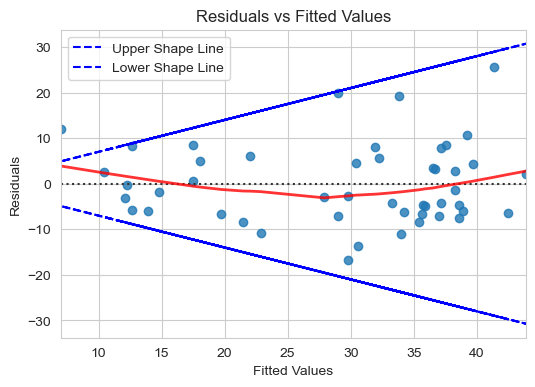

Now if we apply **log transformation** to the above model, we get the below summary of the transformed model:

```
                            OLS Regression Results
==============================================================================
Dep. Variable:     alumni_giving_rate   R-squared:                       0.599
Model:                            OLS   Adj. R-squared:                  0.590
Method:                 Least Squares   F-statistic:                     68.73
Date:                Mon, 20 Nov 2023   Prob (F-statistic):           1.11e-10
Time:                        22:24:27   Log-Likelihood:                -15.511
No. Observations:                  48   AIC:                             35.02
Df Residuals:                      46   BIC:                             38.76
Df Model:                           1
Covariance Type:            nonrobust
=========================================================================================
                            coef    std err          t      P>|t|      [0.025      0.975]
-----------------------------------------------------------------------------------------
const                     4.2362      0.128     33.005      0.000       3.978       4.495
student_faculty_ratio    -0.0851      0.010     -8.291      0.000      -0.106      -0.064
==============================================================================
Omnibus:                        0.012   Durbin-Watson:                   1.642
Prob(Omnibus):                  0.994   Jarque-Bera (JB):                0.096
Skew:                          -0.030   Prob(JB):                        0.953
Kurtosis:                       2.789   Cond. No.                         32.7
==============================================================================

Notes:
[1] Standard Errors assume that the covariance matrix of the errors is correctly specified.
```

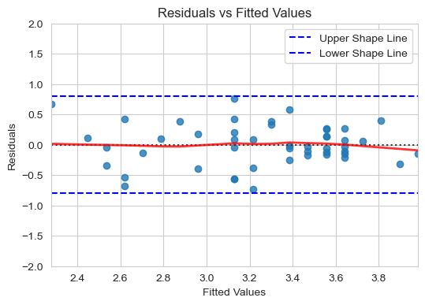

From the transformed model, the transformed equation becomes

**Model 8: $\hat{log(Y)}$ = 4.24 - 0.09X₂.**

Although the primary assumption of Linear Regression is not violated, let us go with the model from the Backward-Elimination/Stepwise-Selection, and we shall chose the best among these two and proceed with Residual Diagnosis. The equation was

**Model 2: $\hat{Y}$ = 41.43 - 1.49X₂ + 7.27X₃.**

Here the p-value of X₃ is 0.138 as reflected in the summary above (2ⁿᵈ summary in the Model Selection section). Which imples if we try to add an interaction term, it would further complicate the model by penalizing AIC and BIC while also further increasing the p-value of X₃ as well as other terms, which would be way beyond our scope of reducing it to below 0.05 by any transformation. Again in this model as p-value of X₃ is 0.138, let us apply log transformation and see the results, which are as below:

```
                            OLS Regression Results
==============================================================================
Dep. Variable:     alumni_giving_rate   R-squared:                       0.638
Model:                            OLS   Adj. R-squared:                  0.622
Method:                 Least Squares   F-statistic:                     39.70
Date:                Tue, 21 Nov 2023   Prob (F-statistic):           1.16e-10
Time:                        11:34:31   Log-Likelihood:                -13.041
No. Observations:                  48   AIC:                             32.08
Df Residuals:                      45   BIC:                             37.70
Df Model:                           2
Covariance Type:            nonrobust
=========================================================================================
                            coef    std err          t      P>|t|      [0.025      0.975]
-----------------------------------------------------------------------------------------
const                     3.6181      0.306     11.830      0.000       3.002       4.234
student_faculty_ratio    -0.0547      0.017     -3.224      0.002      -0.089      -0.021
private                   0.3877      0.176      2.208      0.032       0.034       0.741
==============================================================================
Omnibus:                        0.265   Durbin-Watson:                   1.690
Prob(Omnibus):                  0.876   Jarque-Bera (JB):                0.456
Skew:                          -0.041   Prob(JB):                        0.796
Kurtosis:                       2.529   Cond. No.                         92.1
==============================================================================

Notes:
[1] Standard Errors assume that the covariance matrix of the errors is correctly specified.
```

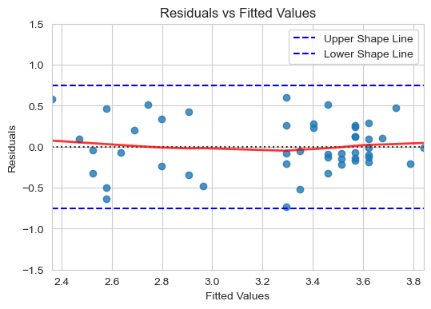

In this model too the primary assumption doesn't seem to be violated and it seems to be a better fit than Model 8 as it has higher ADJ-R² than Model 6 while AIC & BIC values too are lower than that. The p-value of X₃ has now dropped below 0.05. Hence we shall finalize this model and proceed ahead with Residual Diagnosis. Let us term this model as Model 9.

**Model 9: log($\hat{Y}$) = 3.62 - 0.05X₂ + 0.39X₃.**

**NOTE: The intercept term of all the derived equations are inclusive of the error term.**